# More R

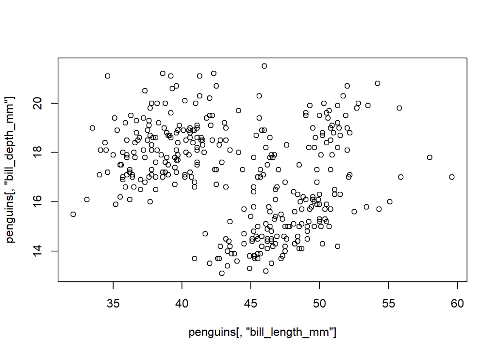

```r
plot(x=penguins[,'bill_length_mm'], y=penguins[,'bill_depth_mm'])
```

OR we can create other types of plots by calling other functions. e.g., a histogram of boxplot:

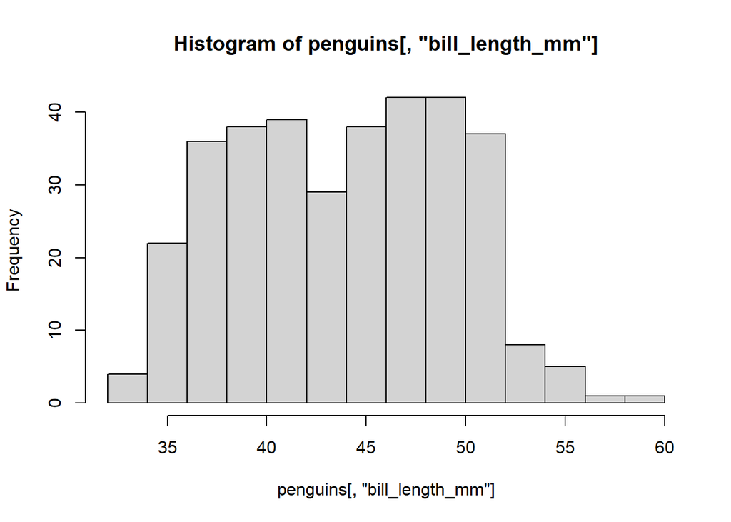

```r
hist(penguins[,'bill_length_mm'])
```

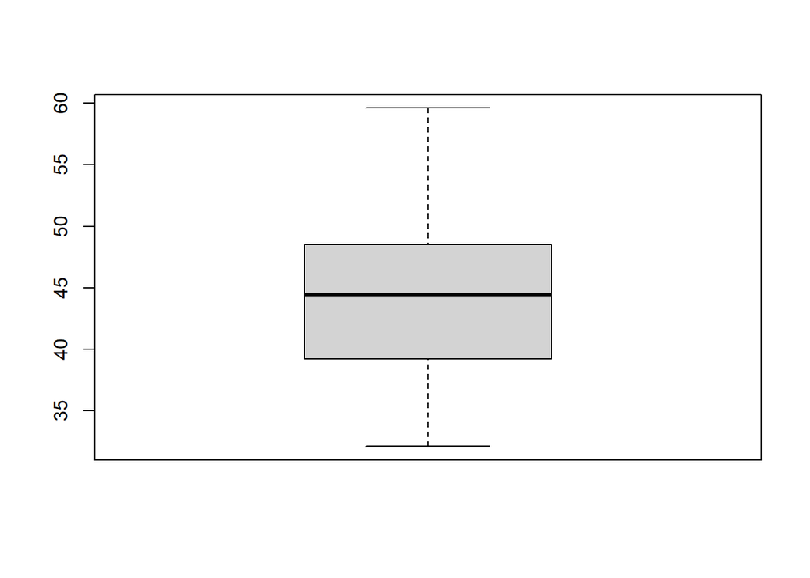

```r
boxplot(penguins[,'bill_length_mm']) #boxplot of bill length
```

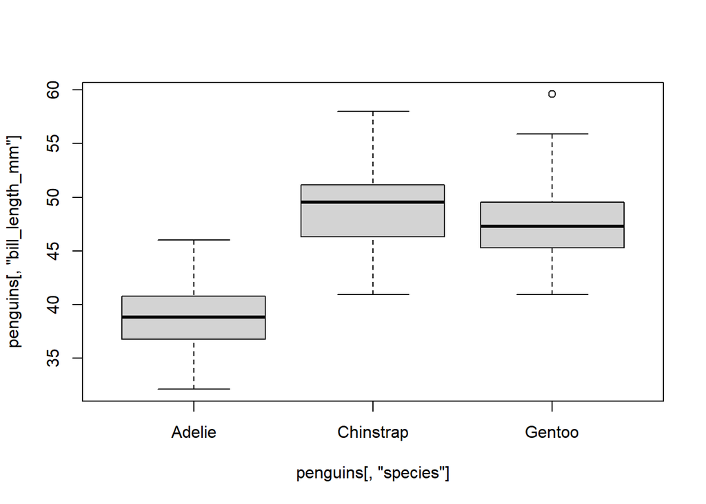

```r
boxplot(penguins[,'bill_length_mm'] ~ penguins[,'species']) # boxplot of bill length by species
```

## Add arguments/modify functions

We can modify the attributes of these plots by manipulating various arguments in the basic functions.

e.g., add colors and change point appearance in a scatterplot:

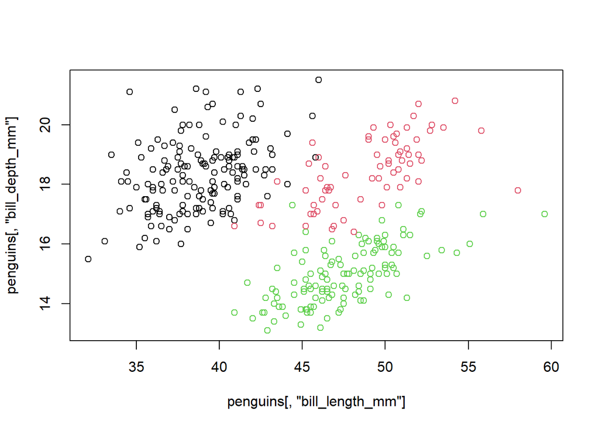

```r
plot(x=penguins[,'bill_length_mm'],
     y=penguins[,'bill_depth_mm'],
     col=as.factor(penguins[,'species'])) # color by species name
```

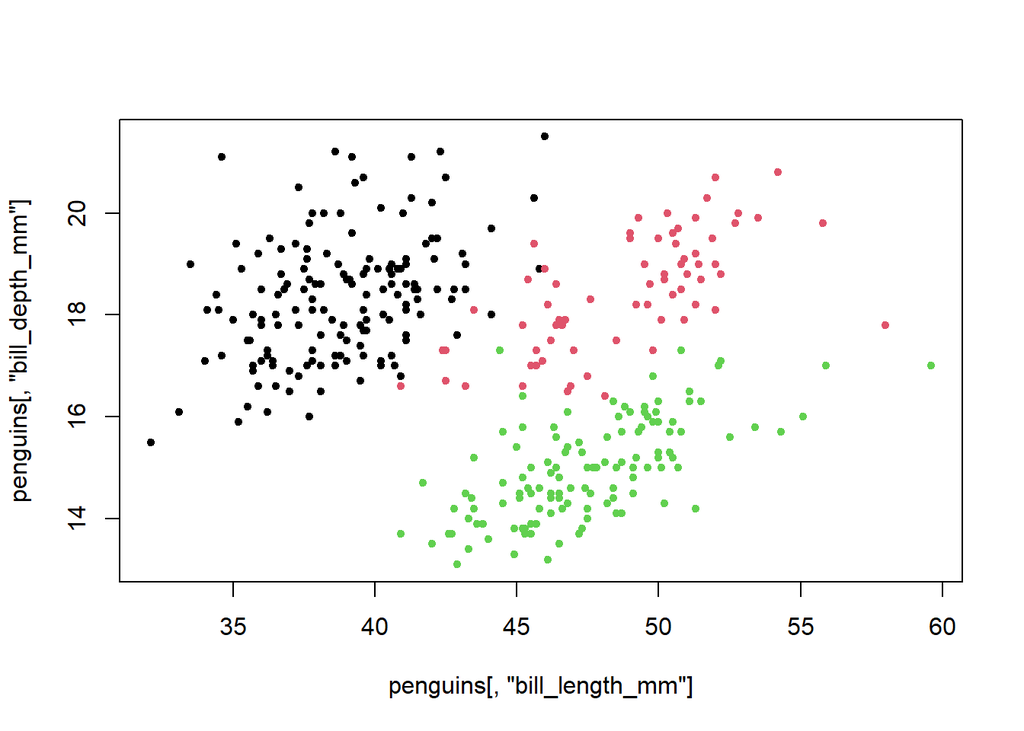

```r
plot(x=penguins[,'bill_length_mm'],
     y=penguins[,'bill_depth_mm'],
     col=as.factor(penguins[,'species']),
     pch=20) #change the points
```

There are lots of [options for ‘pch’ codes](https://www.datanovia.com/en/blog/pch-in-r-best-tips/) that add different symbols.

Now let’s try to clean up the labels on this graph and add a legend.

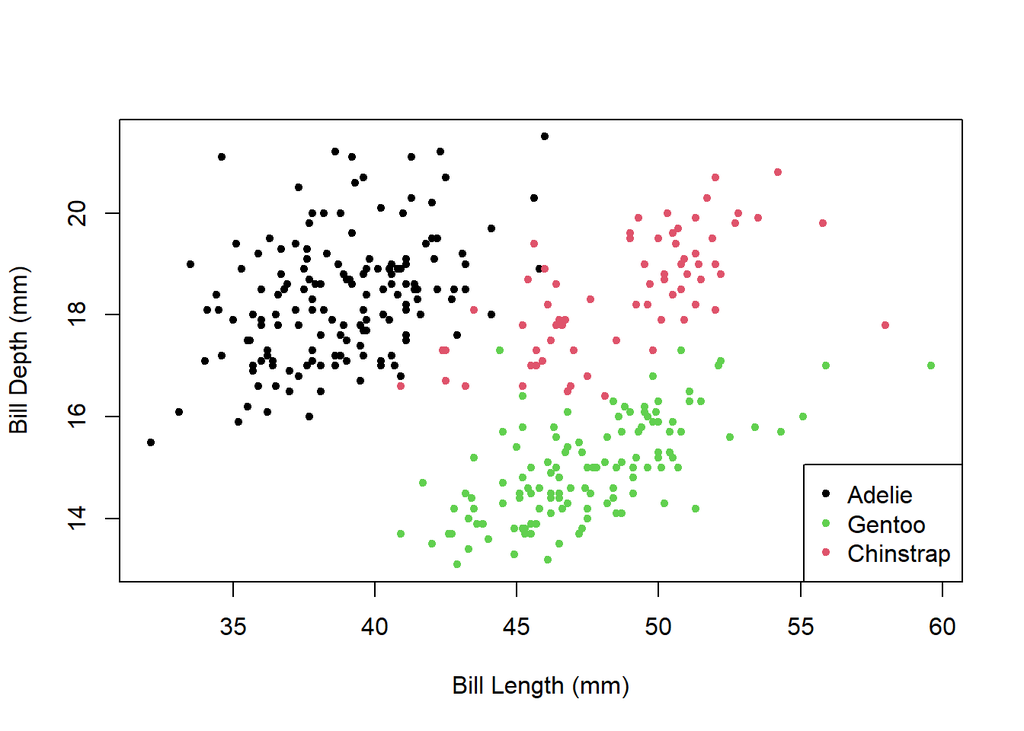

```r
plot(x=penguins[,'bill_length_mm'],
     y=penguins[,'bill_depth_mm'],
     col=as.factor(penguins[,'species']),
     pch=20,
     xlab='Bill Length (mm)',
     ylab='Bill Depth (mm)') # add formatted axis labels


plot(x=penguins[,'bill_length_mm'],
     y=penguins[,'bill_depth_mm'],
     col=as.factor(penguins[,'species']),
     pch=20,
     xlab='Bill Length (mm)',
     ylab='Bill Depth (mm)')
legend('bottomright',
       pch=20,
       legend = unique(as.factor(penguins[,'species'])),
       col = unique(as.factor(penguins[,'species'])))
```

[output not shown]

Ahhh… Finally. A decent graph that has been customized to communicate some of the story these data tell.

# Homework Assignment

1. Read your data into R. Create a simple plot of some of your data. Post it to the [#datacoll](https://introbioinformatics.slack.com/archives/C01K1N821PH) channel.
2. *DISCUSSION*: In the slack [#discussion](https://introbioinformatics.slack.com/archives/C01LSHZFA84) channel we will host this week’s discussion. Please search online for an R related resource for R beginners. This could be a book/eBook, a web tutorial, youtube video, or something else. Post what you find. Look through the resource you found and tell the group about it (what it is, how it is structured, who is the target audience).

# [Home](https://bio331.devbioinformatics.org)